# Homework 7b

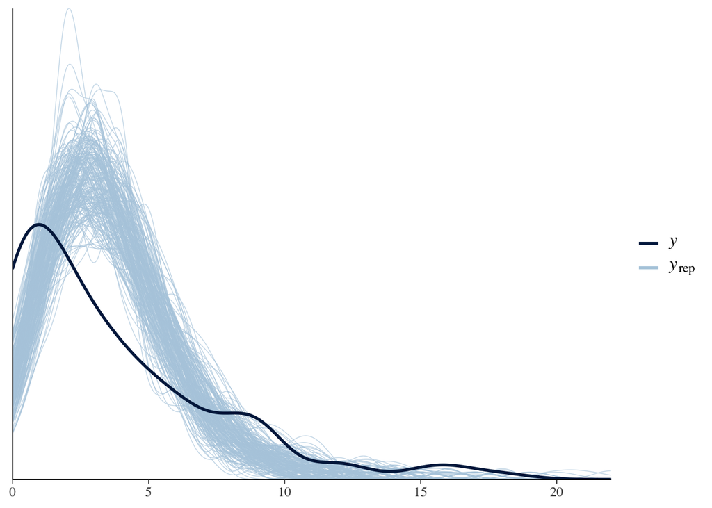

```r
y_rep <- as.matrix(fit_P_real_data, pars = "y_rep")
ppc_dens_overlay(y = stan_dat_simple$complaints, y_rep[1:200,])
```

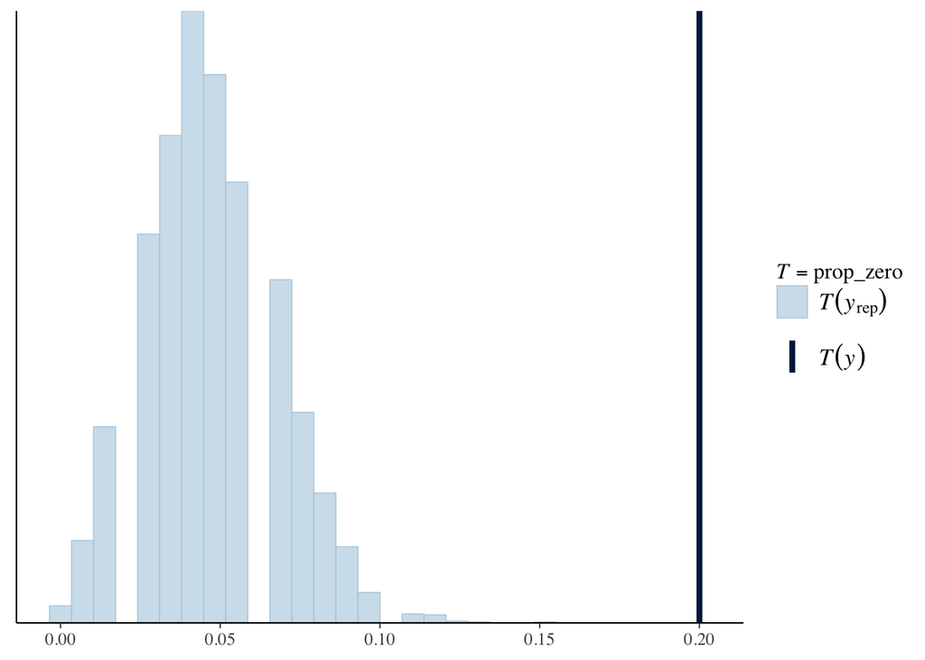

```r
prop_zero <- function(x) mean(x == 0)
ppc_stat(y = stan_dat_simple$complaints, yrep = y_rep, stat = "prop_zero")
```

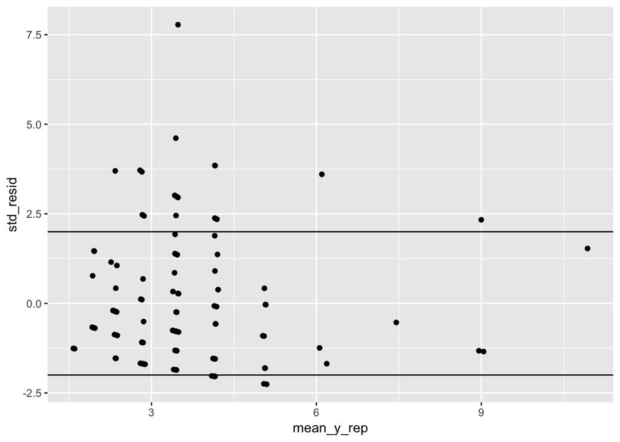

```r
mean_y_rep <- colMeans(y_rep)
std_resid <- (stan_dat_simple$complaints - mean_y_rep) / sqrt(mean_y_rep)
qplot(mean_y_rep, std_resid) + hline_at(2) + hline_at(-2)
```

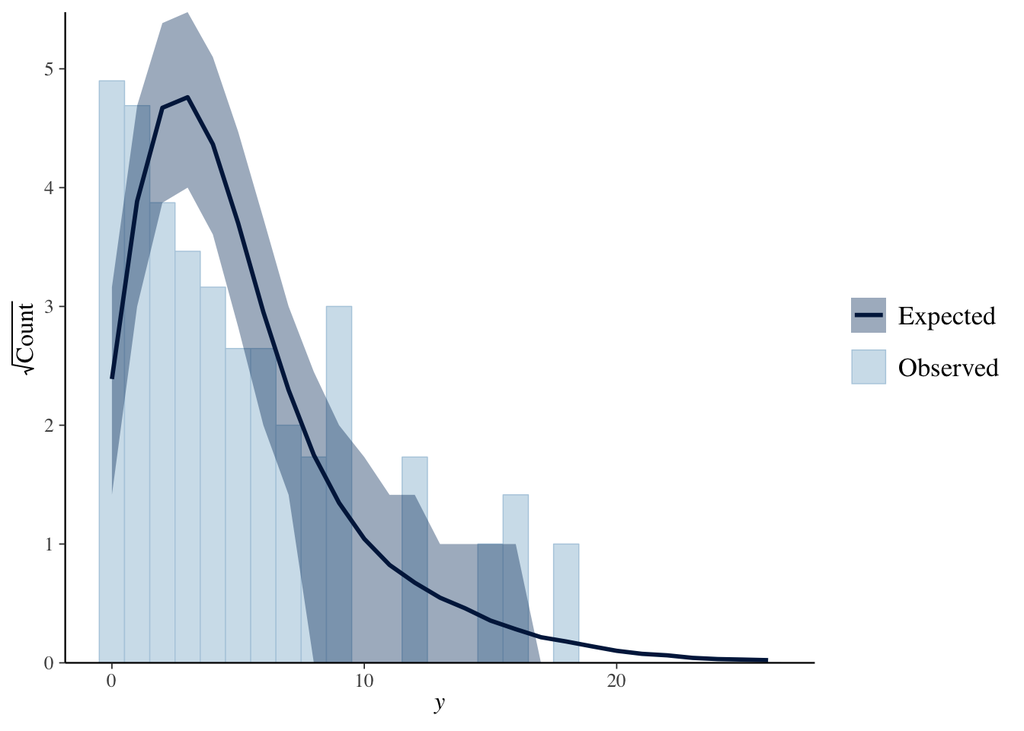

```r
ppc_rootogram(stan_dat_simple$complaints, yrep = y_rep)
```

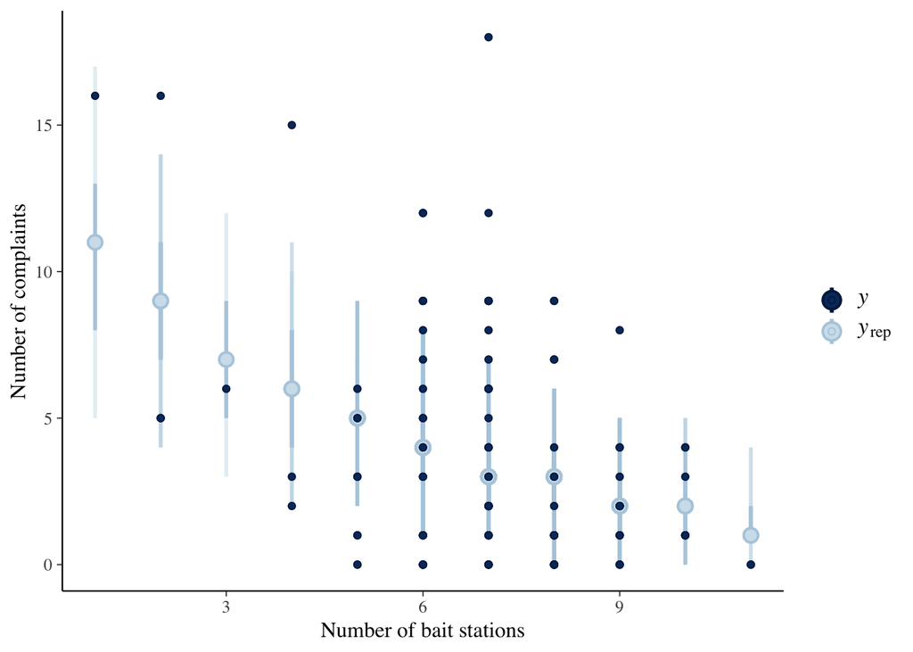

```r
ppc_intervals(y = stan_dat_simple$complaints, yrep = y_rep, x = stan_dat_simple$traps) +
  labs(x = "Number of bait stations", y = "Number of complaints")
```

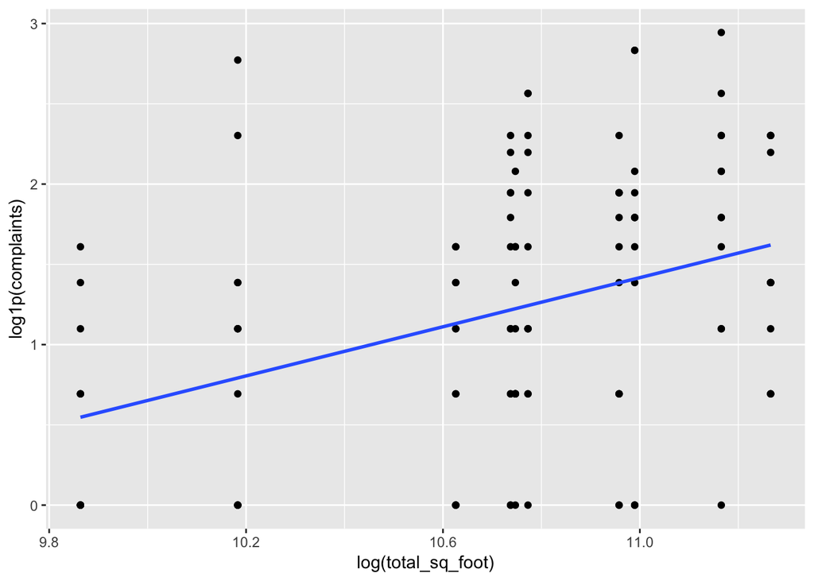

```r
## expanding the model: multiple predictiors
ggplot(pest_data, aes(x = log(total_sq_foot), y = log1p(complaints))) +
  geom_point() +
  geom_smooth(method = "lm", se = FALSE)
```

```r
stan_dat_simple$log_sq_foot <- log(pest_data$total_sq_foot/1e4)
stan_dat_simple$live_in_super <- pest_data$live_in_super

## simulate fake data with multiple predictors
comp_dgp_multiple <- stan_model('multiple_poisson_regression_dgp.stan')
stan_dat_fake <- list(N=nrow(pest_data),
                      mean_traps = mean(pest_data$traps),
                      mean_live_in_super =mean(pest_data$live_in_super),
                      mean_log_sq_foot =  mean(log(pest_data$total_sq_foot)))
fitted_model_dgp <- sampling(comp_dgp_multiple, data = stan_dat_fake,chains = 1, cores = 1, iter = 1, algorithm = 'Fixed_param', seed = 123)
```

```
##
## Iteration: 1 / 1 [100%]  (Sampling)
##
##  Elapsed Time: 0 seconds (Warm-up)
##                5.8e-05 seconds (Sampling)
##                5.8e-05 seconds (Total)
```

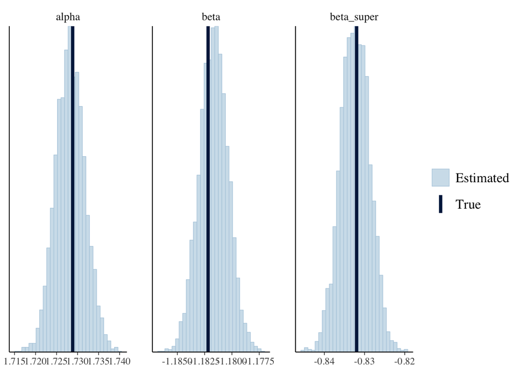

```r
sims_dgp <- extract(fitted_model_dgp)
stan_dat_fake <- list(N = nrow(pest_data), log_sq_foot = sims_dgp$log_sq_foot[1, ],
  live_in_super = sims_dgp$live_in_super[1, ], traps = sims_dgp$traps[1, ], complaints = sims_dgp$complaints[1, ])

comp_model_P_mult <- stan_model('multiple_poisson_regression.stan')
fit_model_P_mult <- sampling(comp_model_P_mult, data = stan_dat_fake, chains = 4, cores = 4)

posterior_alpha_beta <- as.matrix(fit_model_P_mult, pars = c('alpha','beta','beta_super'))
true_alpha_beta <- c(sims_dgp$alpha,sims_dgp$beta,sims_dgp$beta_super)
mcmc_recover_hist(posterior_alpha_beta, true = true_alpha_beta)
```

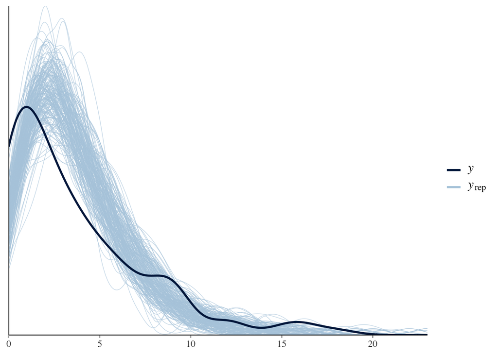

```r
## Fit the data given to us
fit_model_P_mult_real <- sampling(comp_model_P_mult, data = stan_dat_simple)
y_rep <- as.matrix(fit_model_P_mult_real, pars = "y_rep")
ppc_dens_overlay(stan_dat_simple$complaints, y_rep[1:200,])
```

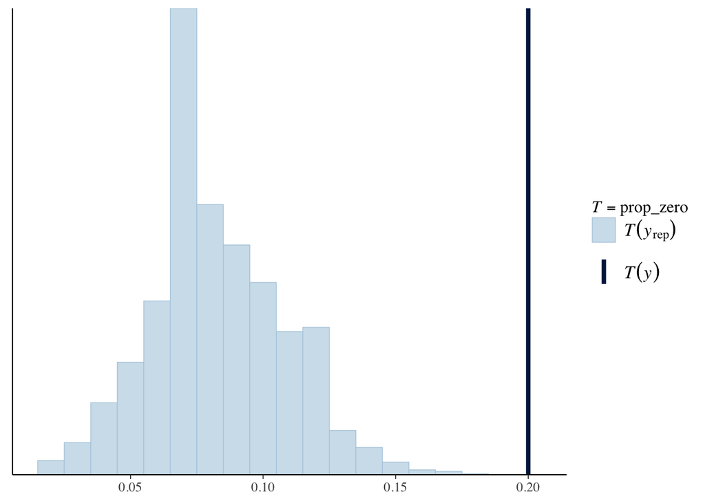

```r
prop_zero <- function(x) mean(x == 0)
ppc_stat(y = stan_dat_simple$complaints, yrep = y_rep, stat = "prop_zero", binwidth = 0.01)
```

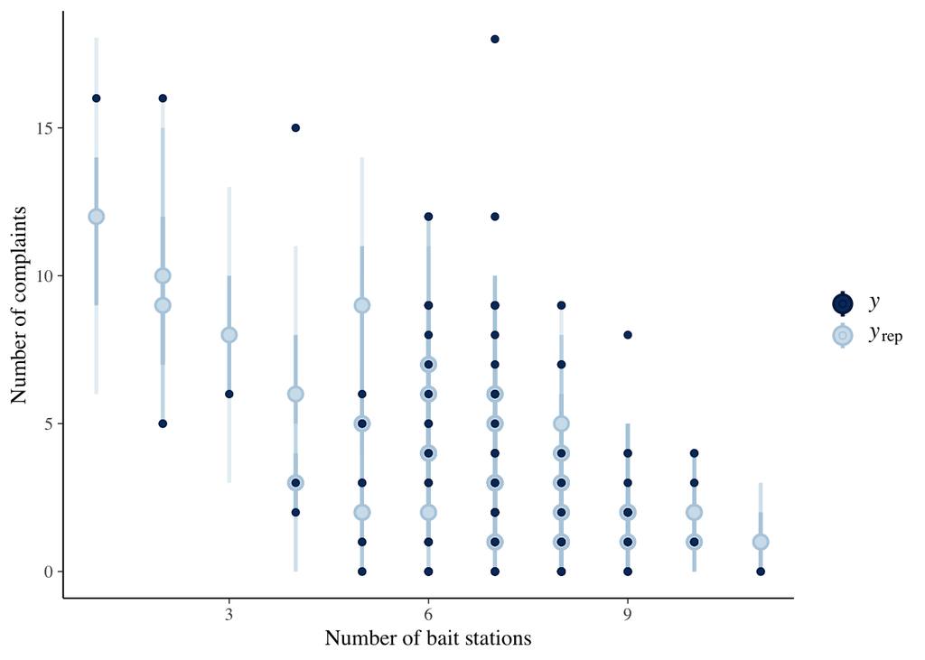

```r
ppc_intervals(y = stan_dat_simple$complaints, yrep = y_rep, x = stan_dat_simple$traps) +
  labs(x = "Number of bait stations", y = "Number of complaints")
```

```r
## Modeling count data with the negative binomial distribution
comp_dgp_multiple_NB <- stan_model('multiple_NB_regression_dgp.stan')
stan_dat_fake <- list(N=nrow(pest_data),
                      mean_traps = mean(pest_data$traps),
                      mean_live_in_super =mean(pest_data$live_in_super),
                      mean_log_sq_foot =  mean(log(pest_data$total_sq_foot)))
fitted_model_dgp_NB <- sampling(comp_dgp_multiple_NB, data = stan_dat_fake,
  chains = 1, cores = 1, iter = 1, algorithm = 'Fixed_param', seed = 123)
```

```
##
## Iteration: 1 / 1 [100%]  (Sampling)
##
##  Elapsed Time: 0 seconds (Warm-up)
##                6.6e-05 seconds (Sampling)
##                6.6e-05 seconds (Total)
```

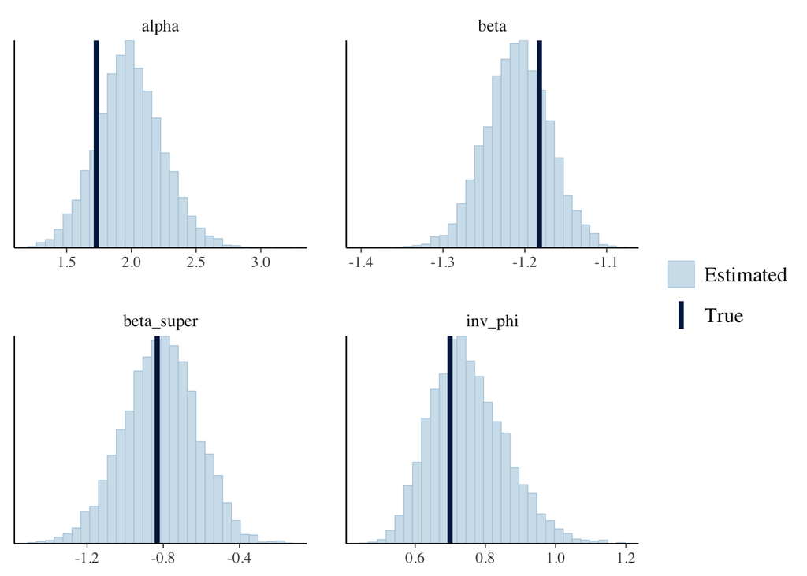

```r
sims_dgp_NB <- extract(fitted_model_dgp_NB)

stan_dat_fake_NB <- list(N = nrow(pest_data),
                         log_sq_foot = sims_dgp_NB$log_sq_foot[1, ],
                         live_in_super = sims_dgp_NB$live_in_super[1, ],
                         traps = sims_dgp_NB$traps[1, ],
                         complaints = sims_dgp_NB$complaints[1, ]
)

comp_model_NB <- stan_model('multiple_NB_regression.stan')

fitted_model_NB <- sampling(comp_model_NB, data = stan_dat_fake_NB,
                            chains = 4, cores = 4)

posterior_alpha_beta_NB <- as.matrix(fitted_model_NB, pars = c('alpha', 'beta', 'beta_super', 'inv_phi'))
true_alpha_beta_NB <- c(sims_dgp_NB$alpha, sims_dgp_NB$beta, sims_dgp_NB$beta_super, sims_dgp_NB$inv_phi)
mcmc_recover_hist(posterior_alpha_beta_NB, true = true_alpha_beta_NB)
```

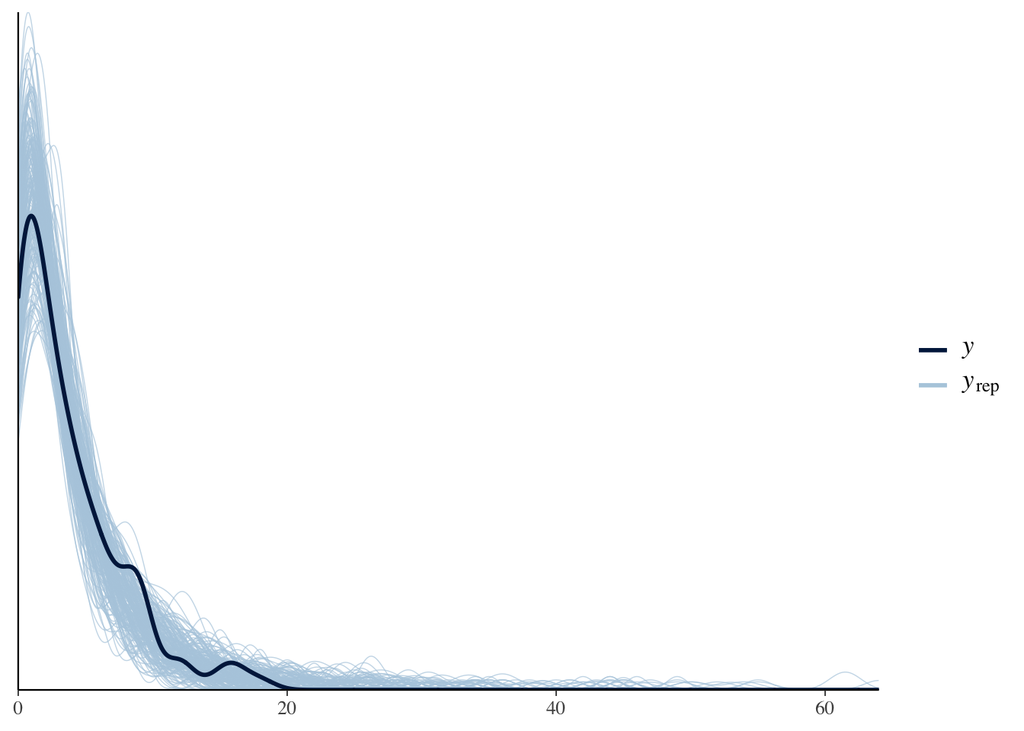

```r
## fiting to the given data and checking the fit
fitted_model_NB <- sampling(comp_model_NB, data = stan_dat_simple)
sims_NB <- extract(fitted_model_NB)

y_rep <- sims_NB$y_rep
ppc_dens_overlay(stan_dat_simple$complaints, y_rep[1:200,])
```

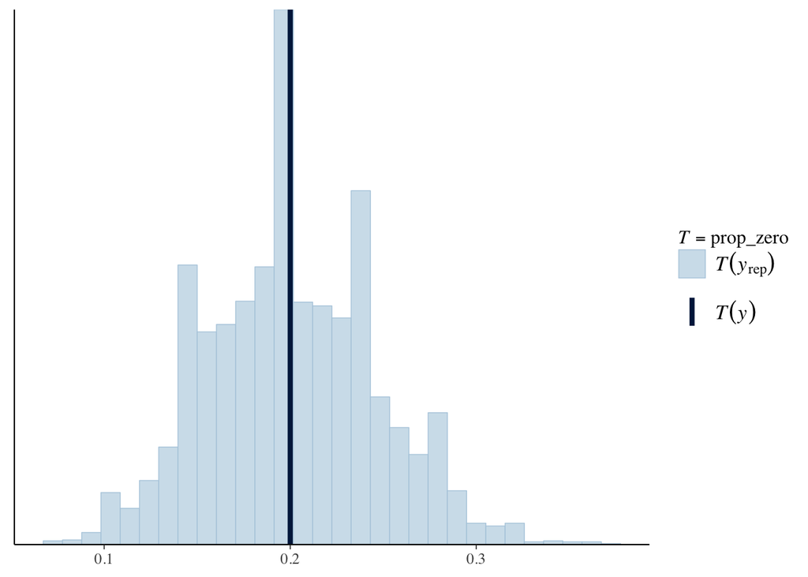

```r
ppc_stat(y = stan_dat_simple$complaints, yrep = y_rep, stat = "prop_zero")
```

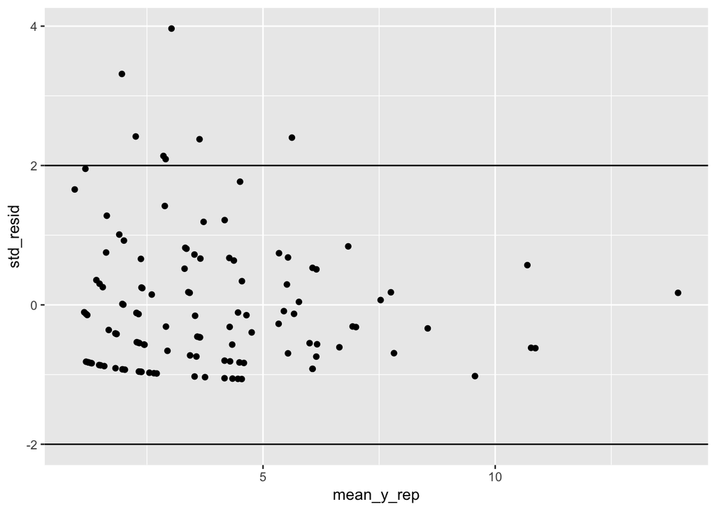

```r
mean_inv_phi <- mean(sims_NB$inv_phi)
mean_y_rep <- colMeans(y_rep)
std_resid <- (stan_dat_simple$complaints - mean_y_rep) / sqrt(mean_y_rep + mean_y_rep^2*mean_inv_phi)
qplot(mean_y_rep, std_resid) + hline_at(2) + hline_at(-2)
```

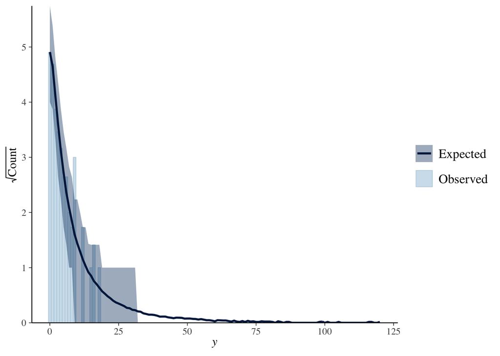

```r
ppc_rootogram(stan_dat_simple$complaints, yrep = y_rep)
```

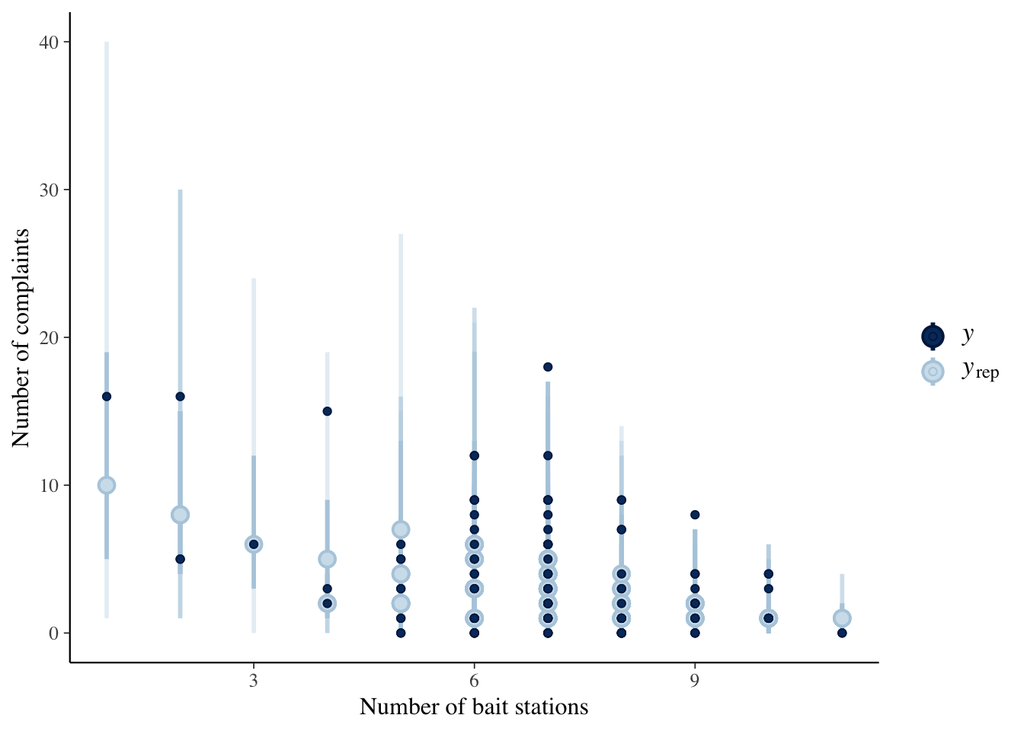

```r
ppc_intervals(y = stan_dat_simple$complaints, yrep = y_rep, x = stan_dat_simple$traps) +
  labs(x = "Number of bait stations", y = "Number of complaints")
```

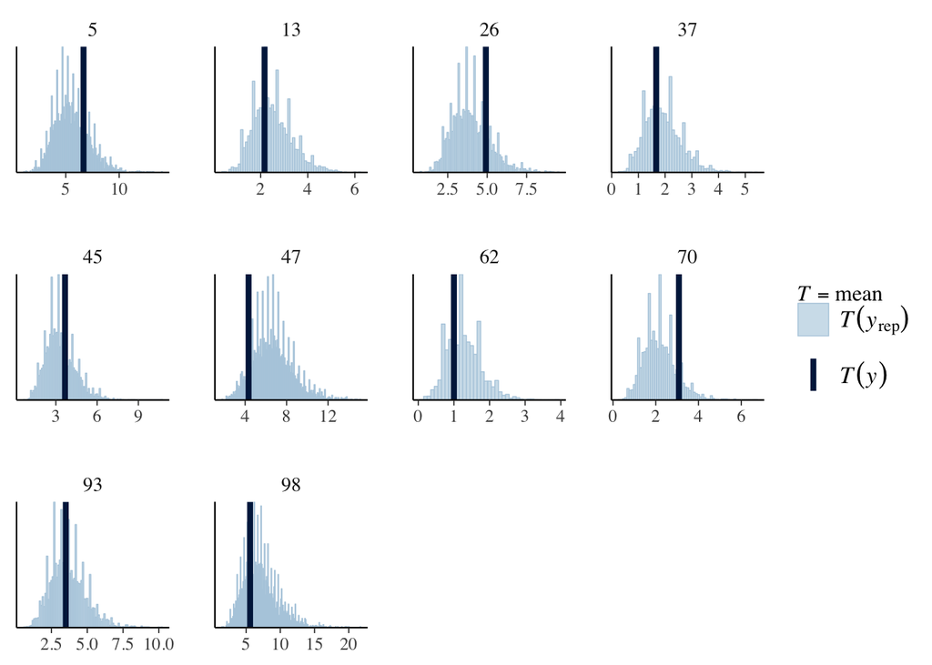

```r
ppc_stat_grouped(y = stan_dat_simple$complaints, yrep = y_rep, group = pest_data$building_id,
  stat = 'mean', binwidth = 0.1)
```

#### 2. Write down a two sentence plan for your final project

A data set about customers’ information (including sex, income, address and so on) as well as log records of website visit would be analyzed with the hierarchical model would be used to predicte the potential (latent variable) and its risk of treatment (latent variable). The data is from a start up company and they are online shopping website.

Since we have log visit record, time-varying effects and structured priors many need to be discussed.

#### 3. What sort of Bayesian modeling do you plan on performing?

hierarchical modeling based on multivariable regression.

#### 4. How might you check your model? (e.g. posterior predictive checks c.f. Chapter 6 of BDA)

First, graphical posterior predictive checks would be done. plots including residual plots and other statistical inference plots would be drawn to get the big picture of the check.

Second, the posterior predictive checks would be done. The basic statistics including mean, standard deviation, max value and min value would be choosen. And we probabily would choose other quantiles for differenct model questions like check whether it is indepent.

Second, marginal predictive checks would be done.

#### 5. How might you evaluate your model? (e.g. cross-validation c.f. Chapter 7 of BDA)

First, the cross-validation would be done. Based on the computation cost, we may choose leave one out cross-validation or others like 10 forld cross-validation.

Second, we would try to use the WAIC which is under the bayesian framework and try to compare the results with the cross-validation and discuss it.

#### 6. How might you collect data? (e.g. ensuring ignorability)

The data have been collected from the company directly. But there would have some missing data problem. These data are observational data we need to use as many covariable as possible to make the design as random as possible.